# scientific-python

- Meist hat man nach in einer Auswertung Datenpunkte, die verarbeitet werden müssen
- Numpy ist eine Python-Bibliothek, die den Umgang mit Datenpunkten enorm vereinfacht

```python
import numpy as np
```

- Grunddatentyp von Numpy: das Array
- Kann man sich als effizientere Liste vorstellen
- Idee von Numpy: Man kann ein Array ähnlich wie eine Zahl verwenden. Operationen werden dann auf allen Elementen ausgeführt
- Am besten versteht man das mit einigen Beispielen:

```python
# convert list to array
x = np.array([1, 2, 3, 4, 5])
```

```python
2 * x
```

```
array([ 2,  4,  6,  8, 10])
```

```python
x**2
```

```
array([ 1,  4,  9, 16, 25])
```

```python
x**x
```

```
array([   1,    4,   27,  256, 3125])
```

```python
np.cos(x)
```

```
array([ 0.54030231, -0.41614684, -0.9899925 , -0.65364362,  0.28366219])
```

Achtung: Man braucht das `cos` aus numpy!

```python
import math
math.cos(x)
```

```
---------------------------------------------------------------------------
TypeError                                 Traceback (most recent call last)
<ipython-input-7-25067472c670> in <module>()
      1 import math
----> 2 math.cos(x)

TypeError: only length-1 arrays can be converted to Python scalars
```

Selbstgeschriebene Funktionen, die nur für eine Zahl geschrieben wurden, funktionieren oft ohne Änderung mit Arrays!

```python
def poly(y):
    return y + 2 * y**2 - y**3

poly(x)
```

```
array([  2,   2,  -6, -28, -70])
```

```python
poly(np.pi)
```

```
-8.125475224531307
```

```python
# this also works:
def poly(x):
    return x + 2 * x**2 - x**3

poly(x)
```

```
array([  2,   2,  -6, -28, -70])
```

Das erlaubt es einem unter anderem sehr leicht physikalische Formeln auf seine Datenpunkte anzuwenden.

Arrays können beliebige Dimension haben:

```python
# two-dimensional array
y = np.array([[1, 2, 3],
              [4, 5, 6],
              [7, 8, 9]])

y + y
```

```
array([[ 2,  4,  6],
       [ 8, 10, 12],
       [14, 16, 18]])
```

Das erlaubt es z.B. eine ganze Tabelle als ein Array abzuspeichern.

Es gibt viele nützliche Funktionen, die bei der Erstellung von Arrays helfen:

```python
np.zeros(10)
```

```
array([ 0.,  0.,  0.,  0.,  0.,  0.,  0.,  0.,  0.,  0.])
```

```python
np.ones((5, 2))
```

```
array([[ 1.,  1.],
       [ 1.,  1.],
       [ 1.,  1.],
       [ 1.,  1.],
       [ 1.,  1.]])
```

```python
np.linspace(0, 1, 11)
```

```
array([ 0. ,  0.1,  0.2,  0.3,  0.4,  0.5,  0.6,  0.7,  0.8,  0.9,  1. ])
```

```python
# like range() for arrays:
np.arange(0, 10)
```

```
array([0, 1, 2, 3, 4, 5, 6, 7, 8, 9])
```

```python
np.logspace(-4, 5, 10)
```

```
array([  1.00000000e-04,   1.00000000e-03,   1.00000000e-02,
         1.00000000e-01,   1.00000000e+00,   1.00000000e+01,
         1.00000000e+02,   1.00000000e+03,   1.00000000e+04,
         1.00000000e+05])
```

## Numpy Indexing

Numpy erlaubt einem sehr bequem bestimmte Elemente aus einem Array auszuwählen

```python
x = np.arange(0, 10)

# like lists:
x[4]
```

```
4
```

```python
# all elements with indices ≥1 and <4:
x[1:4]
```

```
array([1, 2, 3])
```

```python
# negative indices count from the end
x[-1], x[-2]
```

```
(9, 8)
```

```python
# combination:
x[3:-2]
```

```
array([3, 4, 5, 6, 7])
```

```python
# step size
x[::2]
```

```
array([0, 2, 4, 6, 8])
```

```python
# trick for reversal: negative step
x[::-1]
```

```
array([9, 8, 7, 6, 5, 4, 3, 2, 1, 0])
```

```python
y = np.array([x, x + 10, x + 20, x + 30])
y
```

```
array([[ 0,  1,  2,  3,  4,  5,  6,  7,  8,  9],
       [10, 11, 12, 13, 14, 15, 16, 17, 18, 19],
       [20, 21, 22, 23, 24, 25, 26, 27, 28, 29],
       [30, 31, 32, 33, 34, 35, 36, 37, 38, 39]])
```

```python
# comma between indices
y[3, 2:-1]
```

```
array([32, 33, 34, 35, 36, 37, 38])
```

```python
# only one index ⇒ one-dimensional array
y[2]
```

```
array([20, 21, 22, 23, 24, 25, 26, 27, 28, 29])
```

```python
# other axis: (: alone means the whole axis)
y[:, 3]
```

```
array([ 3, 13, 23, 33])
```

```python
# inspecting the number of elements per axis:
y.shape
```

```
(4, 10)
```

Ausgewählten Elementen kann man auch direkt einen Wert zuweisen

```python
y
```

```
array([[ 0,  1,  2,  3,  4,  5,  6,  7,  8,  9],
       [10, 11, 12, 13, 14, 15, 16, 17, 18, 19],
       [20, 21, 22, 23, 24, 25, 26, 27, 28, 29],
       [30, 31, 32, 33, 34, 35, 36, 37, 38, 39]])
```

```python
y[:, 3] = 0
y
```

```
array([[ 0,  1,  2,  0,  4,  5,  6,  7,  8,  9],
       [10, 11, 12,  0, 14, 15, 16, 17, 18, 19],
       [20, 21, 22,  0, 24, 25, 26, 27, 28, 29],
       [30, 31, 32,  0, 34, 35, 36, 37, 38, 39]])
```

Man kann Indexing sogar gleichzeitig auf der linken und rechten Seite benutzen

```python
y[:,0] = x[3:7]
y
```

```
array([[ 3,  1,  2,  0,  4,  5,  6,  7,  8,  9],
       [ 4, 11, 12,  0, 14, 15, 16, 17, 18, 19],
       [ 5, 21, 22,  0, 24, 25, 26, 27, 28, 29],
       [ 6, 31, 32,  0, 34, 35, 36, 37, 38, 39]])
```

Transponieren des Arrays kehrt die Reihenfolge der Indizes um:

```python
y
```

```
array([[ 3,  1,  2,  0,  4,  5,  6,  7,  8,  9],
       [ 4, 11, 12,  0, 14, 15, 16, 17, 18, 19],
       [ 5, 21, 22,  0, 24, 25, 26, 27, 28, 29],
       [ 6, 31, 32,  0, 34, 35, 36, 37, 38, 39]])
```

```python
y.shape
```

```
(4, 10)
```

```python
y.T
```

```
array([[ 3,  4,  5,  6],
       [ 1, 11, 21, 31],
       [ 2, 12, 22, 32],
       [ 0,  0,  0,  0],
       [ 4, 14, 24, 34],
       [ 5, 15, 25, 35],
       [ 6, 16, 26, 36],
       [ 7, 17, 27, 37],
       [ 8, 18, 28, 38],
       [ 9, 19, 29, 39]])
```

```python
y.T.shape
```

```
(10, 4)
```

# Masken

Oft will man Elemente auswählen, die eine bestimmte Bedingung erfüllen.

Hierzu erstellt man zuerst eine Maske (Arrays aus True/False-Werten).

Diese kann man in eckigen Klammern übergeben.

```python
a = np.linspace(0, 2, 11)
b = a**2

print(a >= 1)

print(a[a >= 1])
```

```
[False False False False False  True  True  True  True  True  True]
[ 1.   1.2  1.4  1.6  1.8  2. ]
```

## Reduzieren von Arrays

Viele Rechenoperationen reduzieren ein Array auf einen einzelnen Wert

```python
x
```

```
array([0, 1, 2, 3, 4, 5, 6, 7, 8, 9])
```

```python
np.sum(x)
```

```
45
```

```python
np.prod(x)
```

```
0
```

```python
np.mean(x)
```

```
4.5
```

Standardabweichung

```python
np.std(x)
```

```
2.8722813232690143
```

Fehler des Mittelwerts (geht auch einfacher):

```python
np.std(x, ddof=1) / np.sqrt(len(x))
```

```
0.9574271077563381
```

Schätzer der Standardabweichung

```python
np.std(x, ddof=1)
```

```
3.0276503540974917
```

Differenzen zwischen benachbarten Elementen

```python
z = x**2
np.diff(z)
```

```
array([ 1,  3,  5,  7,  9, 11, 13, 15, 17])
```

## Input / Output

Einlesen aus Textdateien: `genfromtxt`

Sie gibt den Inhalt einer Textdatei als Array zurück.

Das Gegenstück ist `savetxt`.

```python
n = np.arange(11)
x = np.linspace(0, 1, 11)

np.savetxt('test.txt', [n, x])

with open('test.txt', 'r') as f:
    print(f.read())
```

```
0.000000000000000000e+00 1.000000000000000000e+00 2.000000000000000000e+00 3.000000000000000000e+00 4.000000000000000000e+00 5.000000000000000000e+00 6.000000000000000000e+00 7.000000000000000000e+00 8.000000000000000000e+00 9.000000000000000000e+00 1.000000000000000000e+01
0.000000000000000000e+00 1.000000000000000056e-01 2.000000000000000111e-01 3.000000000000000444e-01 4.000000000000000222e-01 5.000000000000000000e-01 6.000000000000000888e-01 7.000000000000000666e-01 8.000000000000000444e-01 9.000000000000000222e-01 1.000000000000000000e+00
```

```python
data = np.array([n, x])

np.savetxt('test.txt', np.column_stack([n, x]))

with open('test.txt', 'r') as f:
    print(f.read())
```

```
0.000000000000000000e+00 0.000000000000000000e+00
1.000000000000000000e+00 1.000000000000000056e-01
2.000000000000000000e+00 2.000000000000000111e-01
3.000000000000000000e+00 3.000000000000000444e-01
4.000000000000000000e+00 4.000000000000000222e-01
5.000000000000000000e+00 5.000000000000000000e-01
6.000000000000000000e+00 6.000000000000000888e-01
7.000000000000000000e+00 7.000000000000000666e-01
8.000000000000000000e+00 8.000000000000000444e-01
9.000000000000000000e+00 9.000000000000000222e-01
1.000000000000000000e+01 1.000000000000000000e+00
```

Man sollte aber immer erklären, was man da abspeichert:

```python
n = np.arange(11)
x = np.linspace(0, 1, 11)

# header schreibt eine Kommentarzeile in die erste Zeile der Datei
np.savetxt('test.txt', np.column_stack([n, x]), header="n x")
with open('test.txt', 'r') as f:
    print(f.read())
```

```
# n x
0.000000000000000000e+00 0.000000000000000000e+00
1.000000000000000000e+00 1.000000000000000056e-01
2.000000000000000000e+00 2.000000000000000111e-01
3.000000000000000000e+00 3.000000000000000444e-01
4.000000000000000000e+00 4.000000000000000222e-01
5.000000000000000000e+00 5.000000000000000000e-01
6.000000000000000000e+00 6.000000000000000888e-01
7.000000000000000000e+00 7.000000000000000666e-01
8.000000000000000000e+00 8.000000000000000444e-01
9.000000000000000000e+00 9.000000000000000222e-01
1.000000000000000000e+01 1.000000000000000000e+00
```

Einlesen der Werte mit `genfromtxt` :

```python
a, b = np.genfromtxt('test.txt', unpack=True)
a, b
```

```
(array([  0.,   1.,   2.,   3.,   4.,   5.,   6.,   7.,   8.,   9.,  10.]),
 array([ 0. ,  0.1,  0.2,  0.3,  0.4,  0.5,  0.6,  0.7,  0.8,  0.9,  1. ]))
```

# SciPy

[figure not shown]

- Baut auf NumPy auf
- Kann numerisch integrieren, DGLs lösen, optimieren, minimieren, …
- Enthält auch physikalische Konstanten und wichtige mathematische Funktionen

```python
# standard error of the mean
from scipy.stats import sem
sem(x)
```

```
0.10000000000000002
```

```python
# physical constants
import scipy.constants as const
const.epsilon_0
```

```
8.854187817620389e-12
```

```python
# convert temperatures:
print(const.C2K(100))
print(const.K2C(100))
```

```
373.15
-173.15
```

```python
# convert angles:
print(np.rad2deg(np.pi))
print(np.deg2rad(90))
```

```
180.0
1.57079632679
```

```python
# more constants (including units and errors)!
list(const.physical_constants.items())[:10]
```

```
[('triton-proton mag. mom. ratio', (1.066639908, '', 1e-08)),
 ('neutron-electron magn. moment ratio', (0.00104066882, '', 2.5e-10)),
 ('fine-structure constant', (0.0072973525664, '', 1.7e-12)),
 ('muon-electron mass ratio', (206.7682826, '', 4.6e-06)),
 ('nuclear magneton in MHz/T', (7.622593285, 'MHz T^-1', 4.7e-08)),
 ('deuteron-neutron mag. mom. ratio', (-0.44820652, '', 1.1e-07)),
 ('hertz-atomic mass unit relationship', (4.4398216616e-24, 'u', 2e-33)),
 ('kilogram-hartree relationship', (2.061485823e+34, 'E_h', 2.5e+26)),
 ('shielded helion mag. mom. to nuclear magneton ratio',
  (-2.12749772, '', 2.5e-08)),
 ('shielded helion magn. moment', (-1.074553024e-26, 'J T^-1', 9.3e-34))]
```

### Achtung

Wenn solche Konstanten genutzt werden, muss das korrekt mitgeteilt, also zitiert werden. Darauf gehen wir nächste Woche im LaTeX-Workshop ein :-)

(Quelle hier: *python-scipy*)

```python
const.physical_constants["proton mass"]
# value, unit, error
```

```
(1.672621898e-27, 'kg', 2.1e-35)
```

## Fitten

Oft möchte man eine Funktion, zum Beispiel eine Erwartung aus der Theorie, an die gemessenen Werte anpassen. Dies nennt man Fit.

```python
# prepare plot
%matplotlib inline
import matplotlib.pyplot as plt
plt.rcParams['figure.figsize'] = (10, 8)
plt.rcParams['font.size'] = 16
```

```
a = 4.97742635551 ± 0.0214390034102
b = 0.070084504726 ± 0.123809150457
```

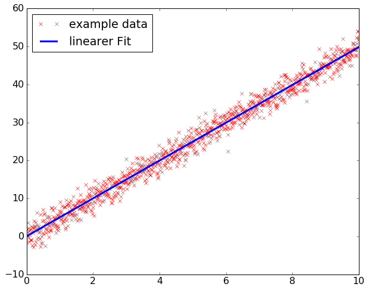

```python
# fit arbitrary functions
from scipy.optimize import curve_fit

x, y = np.genfromtxt('example_data.txt', unpack=True)

def f(x, a, b):
    return a * x + b

params, covariance = curve_fit(f, x, y)
# covariance is the covariance matrix

errors = np.sqrt(np.diag(covariance))

print('a =', params[0], '±', errors[0])
print('b =', params[1], '±', errors[1])

x_plot = np.linspace(0, 10)

plt.plot(x, y, 'rx', label="example data")
plt.plot(x_plot, f(x_plot, *params), 'b-', label='linearer Fit', linewidth=3)
plt.legend(loc="best")
```